# Study habits in public spaces

## Observing Study Behaviour in Shared Spaces

This project is based on observational data logging within public study spaces - mosty libraries and shared university study spaces. Each entry represents what each individual is doing, devices being used, whether they were alone or together and other relevant information. The goal with this data was to reveal some trends surrounding public study behavior.

## What Are Students Doing While Seated in Public Spaces?

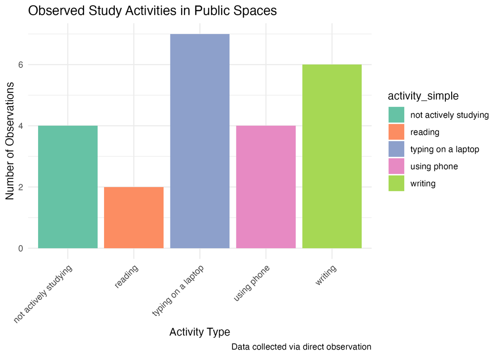

*This Bar plot shows different study activities which were observed.*

This bar plot indicates that digital engagement is very common amongst students (typing & scrolling) appears to be most common. We can see that there is fewer students engaging with paper material (books or writing), indicating that students appear to be focused on more passive less intensive work in public spaces.

## Is Studying Alone Different Than Studying Together?

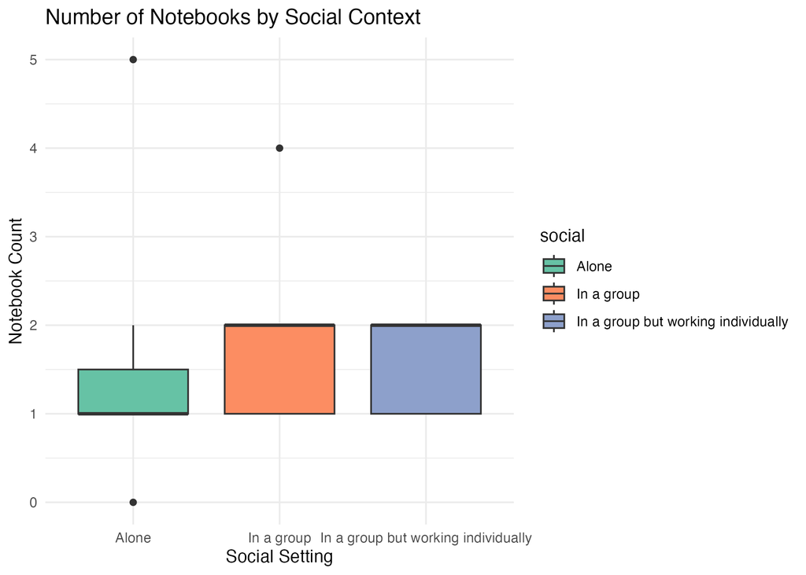

*This is a boxplot which is comparing notebook usage between individual and group study.*

## When Are Students Most Digitally Engaged?

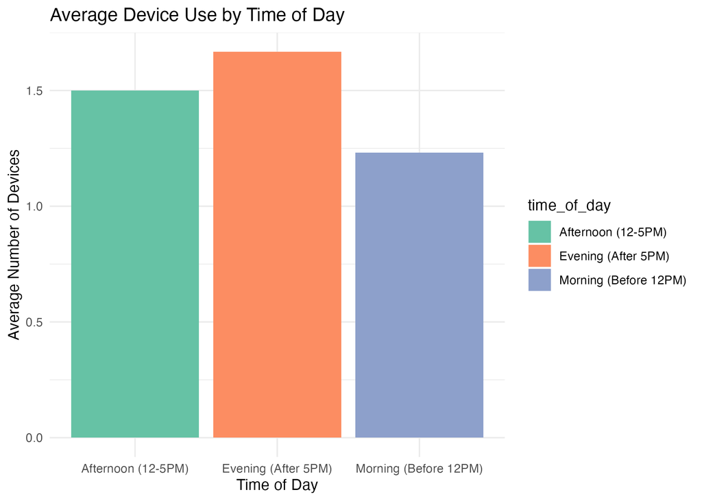

The hours of the evening (after 5PM) appear to have the highest average device usage, followed closely by afternoon and with mornings being the least. This may be indicative of how different students operate, blue light and screen usage in the morning can be difficult for a lot of people due to the strain it places on your mind and eyes, hence afternoon and evening usage makes sense. This may also be a lifestyle choice, maybe the students I have observed are very aware about their health, there could be some bias present.

## Final Thoughts

From this relatively small dataset (n=23), we can begin to see a few patterns be present surrounding study habits in public settings. Device usage appears to dominate, particularly in the evenings and the social context appears to hold some correlation between how intensive studying appears to be. Insights collected from this observational study can assist to inform study space design, technology advantages/constraints and further support around wellness and it’s correlation with students ability to study.